# My Canvas Usage Data Story

## How are University Students utilising their Canvas Experience?

## I have conducted a survey to a group of my friends and colleagues to gain insight and understand how they utilise their Canvas app and access. Consisting of asking students how often they find themselves opening Canvas, what device they tend to use more frequently and the time of which they recorded these entries.

## I personally use Canvas on a regular basis, where I am checking Canvas daily with a minimum of once a day or more depending on the point of the week. Below I have included my first visualisation exploring the amount of times students are engaging with their Canvas application.

## Visualisation 1 - How often are students using Canvas?

[figure not shown]

Visualisation 1 Recorded how often students tend to open their Canvas app on a daily basis

## Canvas as shown in this graph, is relatively essential for University students to keep on top of their work and maintain information for each of their selected courses. A majority of students will have interacted with the application either through the online website or the app that is available on many devices.

## I wanted to understand the volume of how often people are looking at their Canvas app and how that could be displayed in a visualisation. This helped to further compare how I personally use my app and other students’ experiences as well. I found that there are some students who may have more ‘excessive’ amounts of checking their Canvas or students that barely open the app unless prompted or required to.

## Visualisation 2 - What kind of Devices are commonly used amongst students when they attempt to access Canvas?

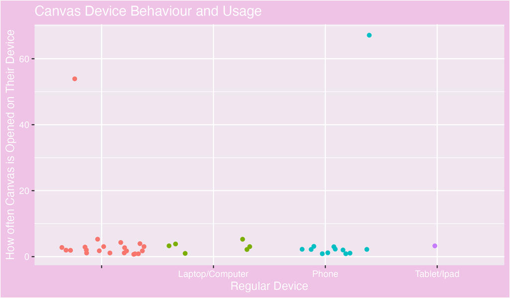

Visualisation 2 showing students main platform for accessing Canvas

## Within the visualisation, it’s clear that the most common “device” was not stated as you can see in the cluster of points that are unlabelled, regardless of the data gap from resusing my prior data with additional questions. It is clear that throughout the collective the majority of Canvas users tend to use their mobile phones to access the app. In comparison using tablets/ipads are less likely on a regular basis.

## This can highlight the accessibility for students, where Canvas is easily downloadable for the general public and available on multiple devices. It’s practical to have the app downloaded on your mobile phone for maximum efficiency when checking assignments, deadlines etc. As this is explored in my later graphs.

## Visualisation 3 - Students Main Reasoning for their Canvas Usage and Time relations

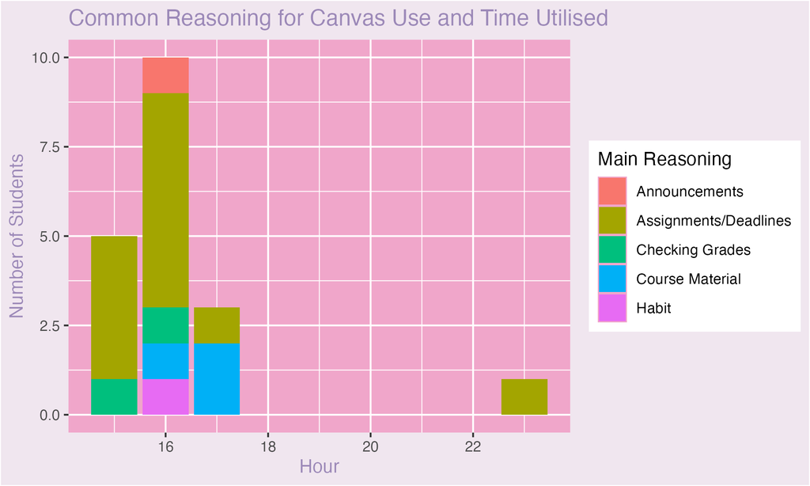

Visualisation 3 Students recorded “main reasoning” as to why they use Canvas, and the times of which they recorded their logging

## Highlighted in this graph is students’ main reasoning as to why they are opening or ‘utilising’ Canvas, considering the app is used for educational purposes and withholds a majority of the information students need to study, communicate and plan out their studies within their courses etc.

## I found that within this graph as well, it is clear that the majority of students tend to use Canvas to check their Assignments/Deadlines over any other purpose. This could highlight on a larger scale where students online traffic withiin the app is based on the concept of trying to keep on top of tasks and upcoming work. There is also a significant amount of data within the graph highlighting the use of Canvas for accessing Course Material.

## Conclusion/Overall Findings

## When collecting this data through my friends/colleagues I had wondered how students who all collectively study but at different levels and within different degrees tend to interact with Canvas.

## Throughout my surveying I had some friends discuss that they constantly feel as if they need to check Canvas as if overnight an assignment could appear at any moment, or that they have randomly missed something that was suddenly due at 9am.. Overall when assessing my findings as well as the visualisations could perform better on a larger scale, possibly with more aspects of other factors.

## For example possibly linkikng the way Canvas is utilised by students in different majors or degrees, is a STEM student more likely to constantly check their Canvas page? how could that differ from someone who studies Humanities, or Law? etc.

## The common trend within all of these visualisations and my surveying is that students inherently have to use Canvas to SOME degree, and analysing how accessible this app is can create discussion on how well this application is being utilised could intersect with performance or grades on a larger scale. Are students who are more likely to pass a class with ‘higher’ grades more inclined to keep on track of their Canvas application and assignments?